# R Assignment - Estimation and CIs

Sanchit Vijay

2022-09-29

This exercise uses the graduate school admissions dataset from the applicants to a higher-ed institute. The dataset is *LogRegAdmit.csv.*

The variables in the dataset are:

- `admit`: 0 or 1 (False or True)
- `gre`: gre score
- `gpa`: grade point average at undergraduate level
- `rank`: the ranking of the applicant’s undergraduate institute, 1, 2, 3, or 4

## Grad School Admissions

### Question 1

**After importing the dataset, check the structure. Make sure `admit` and `rank` are stored as factors, instead of numeric or integers. (Hint: Use as.factor() function or factor() function).**

```r
admissions = data.frame(read.csv("LogRegAdmit.csv"))
admissions$admit = as.factor(admissions$admit)
admissions$rank = as.factor(admissions$rank)
head(admissions)
```

```
##   admit gre  gpa rank
## 1     0 380 3.61    3
## 2     1 660 3.67    3
## 3     1 800 4.00    1
## 4     1 640 3.19    4
## 5     0 520 2.93    4
## 6     1 760 3.00    2
```

```r
cat("Datatype of admit: ", class(admissions$admit))
```

```
## Datatype of admit:  factor
```

```r
cat("\n")
```

```r
cat("Datatype of rank: ", class(admissions$rank))
```

```
## Datatype of rank:  factor
```

‘admit’ and ‘rank’ attributes are stored as factors.

### Question 2

**Construct t-intervals for the `gre` and `gpa` variables for all applicants at 0.80 level and 0.99 level.**

```r
t.test(x = admissions$gre, conf.level = 0.8)
```

```
##
##  One Sample t-test
##
## data:  admissions$gre
## t = 102, df = 399, p-value <2e-16
## alternative hypothesis: true mean is not equal to 0
## 80 percent confidence interval:
##  580 595
## sample estimates:
## mean of x
##       588
```

```r
t.test(x = admissions$gpa, conf.level = 0.8)
```

```
##
##  One Sample t-test
##
## data:  admissions$gpa
## t = 178, df = 399, p-value <2e-16
## alternative hypothesis: true mean is not equal to 0
## 80 percent confidence interval:
##  3.37 3.41
## sample estimates:
## mean of x
##      3.39
```

```r
t.test(x = admissions$gre, conf.level = 0.99)
```

```
##
##  One Sample t-test
##
## data:  admissions$gre
## t = 102, df = 399, p-value <2e-16
## alternative hypothesis: true mean is not equal to 0
## 99 percent confidence interval:
##  573 603
## sample estimates:
## mean of x
##       588
```

```r
t.test(x = admissions$gpa, conf.level = 0.99)
```

```
##
##  One Sample t-test
##
## data:  admissions$gpa
## t = 178, df = 399, p-value <2e-16
## alternative hypothesis: true mean is not equal to 0
## 99 percent confidence interval:
##  3.34 3.44
## sample estimates:
## mean of x
##      3.39
```

### Question 3

**Repeat the same calculation for `gre` in Question 2 but for admitted (1) and rejected (0) separately. (You can subset them first.) Between the admitted and rejected, do the two intervals overlap at 0.80 level? And at 0.99 level?**

```r
gre_subset_adm = subset(admissions, admit == 1)
t.test(x = gre_subset_adm$gre, conf.level = 0.80)
```

```
##
##  One Sample t-test
##
## data:  gre_subset_adm$gre
## t = 64, df = 126, p-value <2e-16
## alternative hypothesis: true mean is not equal to 0
## 80 percent confidence interval:
##  606 631
## sample estimates:
## mean of x
##       619
```

```r
t.test(x = gre_subset_adm$gre, conf.level = 0.99)
```

```
##
##  One Sample t-test
##
## data:  gre_subset_adm$gre
## t = 64, df = 126, p-value <2e-16
## alternative hypothesis: true mean is not equal to 0
## 99 percent confidence interval:
##  594 644
## sample estimates:
## mean of x
##       619
```

```r
gre_subset_rej = subset(admissions, admit == 0)
t.test(x = gre_subset_rej$gre, conf.level = 0.80)
```

```
##
##  One Sample t-test
##
## data:  gre_subset_rej$gre
## t = 82, df = 272, p-value <2e-16
## alternative hypothesis: true mean is not equal to 0
## 80 percent confidence interval:
##  564 582
## sample estimates:
## mean of x
##       573
```

```r
t.test(x = gre_subset_rej$gre, conf.level = 0.99)
```

```
##
##  One Sample t-test
##
## data:  gre_subset_rej$gre
## t = 82, df = 272, p-value <2e-16
## alternative hypothesis: true mean is not equal to 0
## 99 percent confidence interval:
##  555 591
## sample estimates:
## mean of x
##       573
```

Intervals don’t overlap between admitted and rejected region for both 0.80 and 0.99 confidence levels.

### Question 4

**Make (box-) plots showing `gre` distribution among applicants from different school rankings for the admitted and rejected separately. Please use ggplot for this. The x-variable should be `rank`, and the y-variable should be `gre`.**

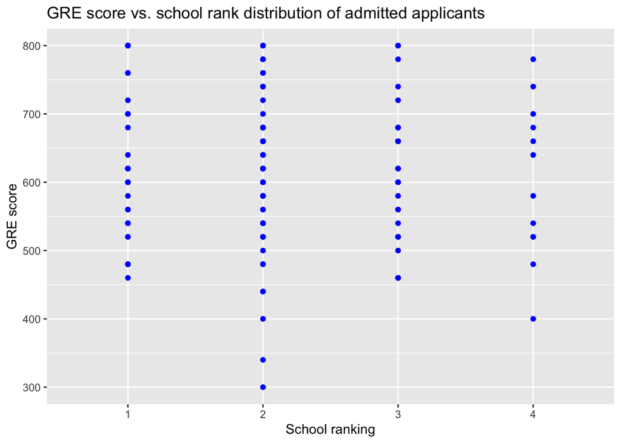

```r
library(ggplot2)

ggplot(gre_subset_adm, aes(x = rank, y = gre)) + geom_point(color = "blue") + labs(title = "GRE score vs. school rank distribution of admitted applicants", x = "School ranking", y = "GRE score")
```

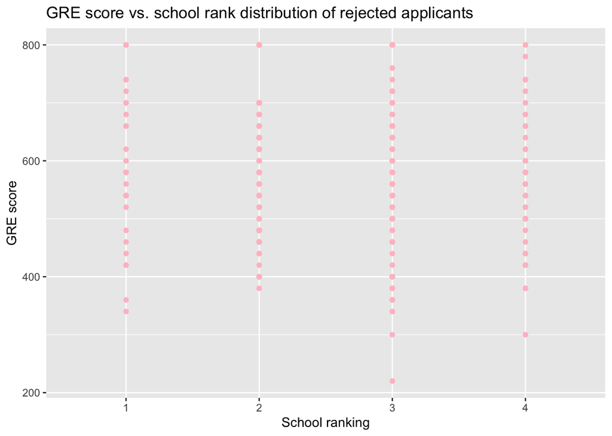

```r
ggplot(gre_subset_rej, aes(x = rank, y = gre)) + geom_point(color = "pink") + labs(title = "GRE score vs. school rank distribution of rejected applicants", x = "School ranking", y = "GRE score")
```

### Question 5

**Repeat Question 2 and Question 3 for `gpa`. Do the two groups have t-intervals overlap at 0.80 level? At 0.99 level?**

```r
gpa_subset_adm = subset(admissions, admit == 1)
t.test(x = gpa_subset_adm$gpa, conf.level = 0.80)
```

```
##
##  One Sample t-test
##
## data:  gpa_subset_adm$gpa
## t = 106, df = 126, p-value <2e-16
## alternative hypothesis: true mean is not equal to 0
## 80 percent confidence interval:
##  3.45 3.53
## sample estimates:
## mean of x
##      3.49
```

```r
t.test(x = gpa_subset_adm$gpa, conf.level = 0.99)
```

```
##
##  One Sample t-test
##
## data:  gpa_subset_adm$gpa
## t = 106, df = 126, p-value <2e-16
## alternative hypothesis: true mean is not equal to 0
## 99 percent confidence interval:
##  3.40 3.58
## sample estimates:
## mean of x
##      3.49
```

```r
gpa_subset_rej = subset(admissions, admit == 0)
t.test(x = gpa_subset_rej$gpa, conf.level = 0.80)
```

```
##
##  One Sample t-test
##
## data:  gpa_subset_rej$gpa
## t = 146, df = 272, p-value <2e-16
## alternative hypothesis: true mean is not equal to 0
## 80 percent confidence interval:
##  3.31 3.37
## sample estimates:
## mean of x
##      3.34
```

```r
t.test(x = gpa_subset_rej$gpa, conf.level = 0.99)
```

```
##
##  One Sample t-test
##
## data:  gpa_subset_rej$gpa
## t = 146, df = 272, p-value <2e-16
## alternative hypothesis: true mean is not equal to 0
## 99 percent confidence interval:
##  3.28 3.40
## sample estimates:
## mean of x
##      3.34
```

### Question 6

**Repeat Question 4 for `gpa`. Make (box-) plots showing the gpa distribution among applicants from different school rankings for the admitted and rejected separately. Again, use ggplot.**

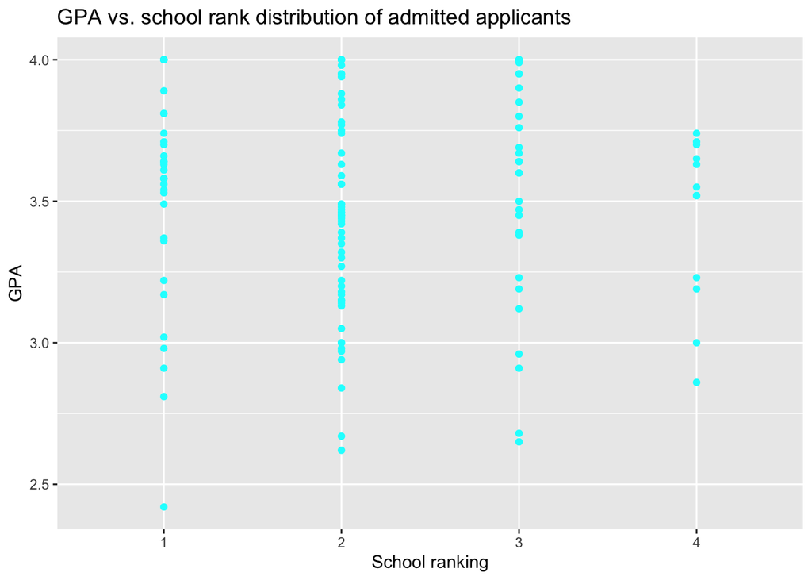

```r
ggplot(gpa_subset_adm, aes(x = rank, y = gpa)) + geom_point(color = "cyan") + labs(title = "GPA vs. school rank distribution of admitted applicants", x = "School ranking", y = "GPA")
```

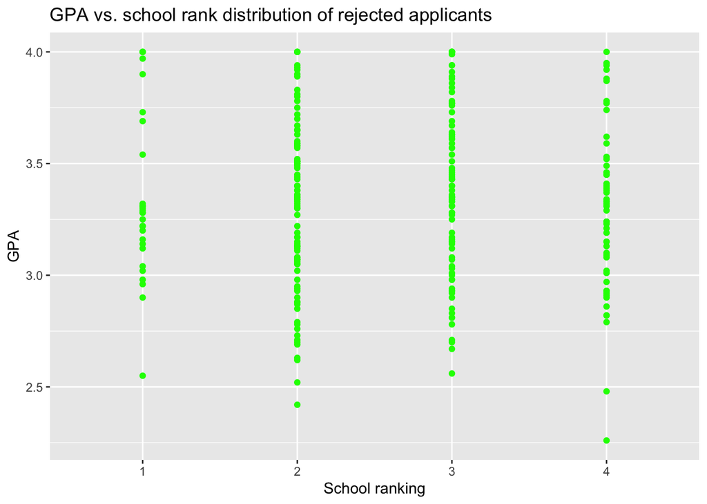

```r
ggplot(gpa_subset_rej, aes(x = rank, y = gpa)) + geom_point(color = "green") + labs(title = "GPA vs. school rank distribution of rejected applicants", x = "School ranking", y = "GPA")
```

### Question 7

**Based on EDA from the charts and the t-interval calculations you produced, do you observe any potential effects between gre/gpa/rank on admissions? Explain briefly.**

```r
# ggplot(gpa_subset_adm, aes(x = gre, y = gpa, color = rank)) + geom_point() + labs(title = "GPA vs. school rank distribution of admitted applicants", x = "GRE", y = "GPA")
# ggplot(gpa_subset_rej, aes(x = gre, y = gpa, color = rank)) + geom_point() + labs(title = "GPA vs. school rank distribution of admitted applicants", x = "GRE", y = "GPA")
```